# Visualising and analysing paleoclimate model outputs

## Part 1: Introduction to the model outputs

The aim of this handbook is to introduce you to visualising and analysing paleoclimate model outputs. For this, we will analyse some "real" existing paleoclimate model outputs, rather than running a model yourself to create the outputs. Running climate models requires access to, and dedicated time on a supercomputing resource, which can be very expensive. However, many institutions make their climate model outputs public so you can download simulations and analyse them yourself.

Here, we examine simulations that have been carried out with the UK Met Office climate model, HadCM3, by researchers in the Paleo Modelling Group in the School of Geographical Sciences at the University of Bristol, UK. This is a quite an old model now, but it is one of the best climate models available that is computationally efficient enough to be run a large number (an 'ensemble') of simulations for many thousands of years, allowing the simulations to come to full equilibrium, even in the deep ocean. The model is described in detail in Valdes et al (2017).

We will start off by downloading outputs from Lunt et al (2008), which was the first paper I wrote that used simulations that I had carried out using the HadCM3 model. It was exploring the impact of the closure of the Panama Seaway in the Pliocene, ~3 million years ago. I carried out 3 simulations; a modern preindustrial control simulation (called 'xbmsc'), a pre-closure Pliocene simulation with a open Panama Seaway ('xbmsb'), and a post-closure Pliocene simulation with an closed Panama Seaway ('xbmsa').  
You can download annual-mean data from the closed-Seaway simulation here: https://www.paleo.bristol.ac.uk/ummodel/data/xbmsa/climate/xbmsaa.pdclann.nc.

You can download annual-mean data from the open-Seaway simulation here: https://www.paleo.bristol.ac.uk/ummodel/data/xbmsb/climate/xbmsba.pdclann.nc.

These files are in 'netCDF format' (.nc) which is a format commonly produced by climate models https://help.ceda.ac.uk/article/106-netcdf .

## Part 2: Package setup

Nearly all climate model output is in 'netcdf' format, with an extension '.nc'. Netcdf is a binary format so you cannot read it directly as text, but Python has several different libraries that can read netcdfs. We will need to make sure that you have the correct library installed. Type the appropriate line below in a cell, and run it. You should only do this once, to install a package not already included in Anaconda or your own Python environment: `!pip install netCDF4`. If this doesn't work then see the Intro to Coding handbook for a guide to installing pcakages.

Now that the netCDF4 library is installed, you can import it using an 'alias' that you will refer to when using this package, called 'nc' :

```python
import netCDF4 as nc
```

There are a few other libraries and modules we will need for this handbook (a library is a group of modules). Import them, installing first where necessary (numpy and matplotlib will likely already be installed, but an install will likely be needed for cartopy if you have not done so already - and note that you will need version 0.24.1 of cartopy - see the Intro to Coding handbook).

```python
# SET UP LIBRARIES AND MODULES
import numpy as np # library
import matplotlib.pyplot as plt # module
import matplotlib.colors as mcolors
import matplotlib.patches as mpatches
import cartopy.crs as ccrs
import cartopy.util as cutil
import cartopy.feature as cfeature
import requests
```

## Part 3: Making a global map

### Reading in files

We will now read in the climate model output that you downloaded above from Lunt et al (2008). We will try to re-create Figure 2 from that paper, which is a global map of temperature change when the Seaway closes (i.e. xbmsa-xbmsb).

You will first need to make a directory and sub-directory at the same level as your working directory that holds your .ipnyb Jupyter notebook, called `Data/panama`, and put the model outputs that you downloaded above into this directory (python is most robust when working with relative paths rather than absolute paths).

We will then read in the results from the closed Seaway simulation (xbmsa):

```python
# Specify the path to your NetCDF file
file_path_1 = 'Data/panama/xbmsaa.pdclann.nc'

# Open the NetCDF file
dataset = nc.Dataset(file_path_1, 'r')
```

### Extracting variables

We can now inspect the contents of this file. This will list all the variables that are stored in this file:

```python
# Print the structure of the file (dimensions, variables, etc.)
print(dataset)
```

```
<class 'netCDF4.Dataset'>
root group (NETCDF3_CLASSIC data model, file format NETCDF3):
    history: Mon Mar 20 17:19:25 GMT 2006 - XCONV V1.91 Development
    dimensions(sizes): longitude(96), latitude(73), hybrid_p_x1000(1), t(1), hybrid_p_x1000_1(19), unspecified(1), surface(1), toa(1), Trop(1), level6(1), hybrid_p_x1000_2(1), longitude_1(96), latitude_1(72), ht(1), level275(1), t_1(8), longitude_2(1), level6_1(4), msl(1), blht(1)
    variables(dimensions): float32 longitude(longitude), float32 latitude(latitude), float32 hybrid_p_x1000(hybrid_p_x1000), float32 t(t), float32 moistureQTFlux_mm_hyb(t, hybrid_p_x1000, latitude, longitude), float32 hybrid_p_x1000_1(hybrid_p_x1000_1), float32 cldamount_mm_hyb(t, hybrid_p_x1000_1, …
    groups:
```

As you can see, there are a lot of variables! Most of the names are reasonably self-explanatory, but if you are uncertain then see [this document](https://www.paleo.bristol.ac.uk/ummodel/scripts/papers/Using_BRIDGE_webpages.pdf). In a netCDF file, data has 'dimensions' to describe the structure of a variable. Most variables have a strucutre (time x level x latitude x longitude). 'Latitude' is of size 73, and 'longitude' is of size 96 (see the 'dimensions' list in the output above). But 'time' is only of size 1, as are most 'level', and so most variables are essentially 2-dimensional latitude-longitude global maps of data. We are going to read in the near-surface air temperature. 'near-surface' in this case is 1.5 metres above the surface. The variable name is 'temp_mm_1_5m'. Note that because this variable is actually 4-dimensional (even though two of the dimensions have size 1), we need to make sure we extract third (latitude) and fourth (longitude) dimensions. We will also read in the longitudes and latitudes themselves, which will allow us to make the plot correctly. We'll also print the latitudes and longitudes to make sure all looks OK (we won't print out the temperature as this would be 96x73 = 7008 numbers!). We can then close this dataset as we won't need it any more.

```python
# Access a specific variable.
# the '[:].data' ensures that we just read in the values, and not any spurious masking
temp = dataset.variables['temp_mm_1_5m'][:].data
lat = dataset.variables['latitude']
lon = dataset.variables['longitude']


# Read the data from the variable
mylat = lat[:]
mylon = lon[:]
# note that temp is 4-dimensional, but mytemp_1 is 2-dimensional
mytemp_1 = temp[0,0,:,:]

print(mylat)
print(mylon)

# Close the dataset
dataset.close()
```

```
[ 90.   87.5  85.   82.5  80.   77.5  75.   72.5  70.   67.5  65.   62.5
  60.   57.5  55.   52.5  50.   47.5  45.   42.5  40.   37.5  35.   32.5
  30.   27.5  25.   22.5  20.   17.5  15.   12.5  10.    7.5   5.    2.5
   0.   -2.5  -5.   -7.5 -10.  -12.5 -15.  -17.5 -20.  -22.5 -25.  -27.5
 -30.  -32.5 -35.  -37.5 -40.  -42.5 -45.  -47.5 -50.  -52.5 -55.  -57.5
 -60.  -62.5 -65.  -67.5 -70.  -72.5 -75.  -77.5 -80.  -82.5 -85.  -87.5
 -90. ]
[  0.     3.75   7.5   11.25  15.    18.75  22.5   26.25  30.    33.75
  37.5   41.25  45.    48.75  52.5   56.25  60.    63.75  67.5   71.25
  75.    78.75  82.5   86.25  90.    93.75  97.5  101.25 105.   108.75
 112.5  116.25 120.   123.75 127.5  131.25 135.   138.75 142.5  146.25
 150.   153.75 157.5  161.25 165.   168.75 172.5  176.25 180.   183.75
 187.5  191.25 195.   198.75 202.5  206.25 210.   213.75 217.5  221.25
 225.   228.75 232.5  236.25 240.   243.75 247.5  251.25 255.   258.75
 262.5  266.25 270.   273.75 277.5  281.25 285.   288.75 292.5  296.25
 300.   303.75 307.5  311.25 315.   318.75 322.5  326.25 330.   333.75
 337.5  341.25 345.   348.75 352.5  356.25]
```

We'll now do the same but for the open seaway simulation, xbmsb (we don't need to read in lat and lon again as they are the same in both files):

```python
file_path_2 = 'Data/panama/xbmsba.pdclann.nc'
dataset = nc.Dataset(file_path_2, 'r')
temp = dataset.variables['temp_mm_1_5m'][:].data
lat = dataset.variables['latitude']
lon = dataset.variables['longitude']
mytemp_2 = temp[0,0,:,:]
dataset.close()
```

We can now simply calculate the difference in temperature between the two runs, closed Seaway minus open Seaway:

```python
temp_diff=mytemp_1-mytemp_2
```

### Global maps

We will now make the 'basic' plot itself. We'll do this using the 'cartopy' library, which seems to be fairly standard currently for climate model plots.

You will first need to make a directory at the same level as your .ipnyb Jupyter notebook (i.e. in your working directory), called ```plots`` .

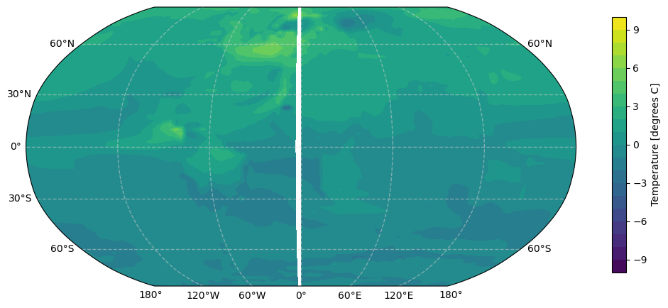

```python
# size 10 by 6 inches gives a nice aspect ratio
fig = plt.figure(figsize=(10, 6))

# The Robinson projection is standard for IPCC.  We'll centre on 0 longitude.
ax = plt.axes(projection=ccrs.Robinson(central_longitude=0))

# add dashed gridlines with a width of 1.0, in light-grey, and 50% transparency
gl = ax.gridlines(crs=ccrs.PlateCarree(), draw_labels=True,
                  linewidth=1, color='lightgray', alpha=0.5, linestyle='--')
# This makes the plot gridlines look less cluttered, removing the top and right labels
# (note that there is a bug in cartopy in that right_labels is False but it still prints 60oN/S annoyingly!)
gl.top_labels = False
gl.right_labels = False

# Define the colour bar limits.  We'll go from -10 to 10, in a step of 1 (= 20 levels)
min_level=-10
max_level=10
step_level=1
my_levs=np.arange(min_level, max_level+step_level, step_level)

# Make the contour plot
contour=plt.contourf(mylon, mylat, temp_diff, transform=ccrs.PlateCarree(central_longitude=0),levels=my_levs)

# Make the colour legend (add_axes positions the colour bar, [left, bottom, width, height])
colorbar_axes = fig.add_axes([0.95, 0.2, 0.02, 0.6])
cbar=plt.colorbar(contour,cax=colorbar_axes,label='Temperature [degrees C]')

# output as a pdf
plt.savefig('plots/panama.pdf', format='pdf', bbox_inches='tight')
# and/or as a png:
plt.savefig('plots/panama.png', format='png', bbox_inches='tight')
```

OK, this plot doesn't look too bad, but it's not great! There are a few things that we can do to make this plot look prettier. We will add a "cyclic" point to the longitudes variable and to the temperature. This gets rid of the white line down the middle:

```python
mylonc=np.ma.append(mylon,mylon[0]+360.0)
temp_diffc=cutil.add_cyclic_point(temp_diff)
```

And we can change the limits of the colour scale to better fit the data, add a continental outline, and modify the colour table, to make a publication-quality plot:

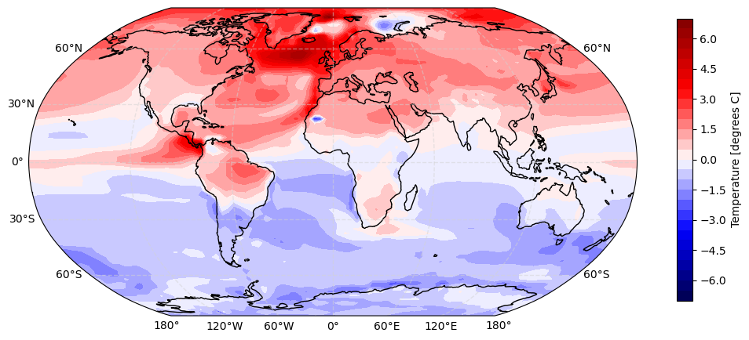

```python
fig = plt.figure(figsize=(10, 6))
ax = plt.axes(projection=ccrs.Robinson(central_longitude=0))

# add a modern continental outline:
ax.coastlines()

gl = ax.gridlines(crs=ccrs.PlateCarree(), draw_labels=True,
                  linewidth=1, color='lightgray', alpha=0.5, linestyle='--')
gl.top_labels = False
gl.right_labels = False

# Define the colour bar to have more appropriate limits
min_level=-7
max_level=7
step_level=0.5
my_levs=np.arange(min_level, max_level+step_level, step_level)

# use the seismic colour map in place of the default:
contour=plt.contourf(mylonc, mylat, temp_diffc, transform=ccrs.PlateCarree(central_longitude=0),levels=my_levs,cmap='seismic')

colorbar_axes = fig.add_axes([0.95, 0.2, 0.02, 0.6])
cbar=plt.colorbar(contour,cax=colorbar_axes,label='Temperature [degrees C]')
plt.savefig('plots/panama_new.pdf', format='pdf', bbox_inches='tight')
```

**Q: Why does closing the Panama Seaway in the model lead to this strong hemispherically asymmetric temperature response?**

## Part 4: Other maps

### Regional maps and proxies

A few other things that you might want to do are (1) zoom in on a particular region, (2) show the actual gridboxes, instead of contouring which can disguise the model resolution, and (3) plot some geologically-derived proxy temperature observations on top:

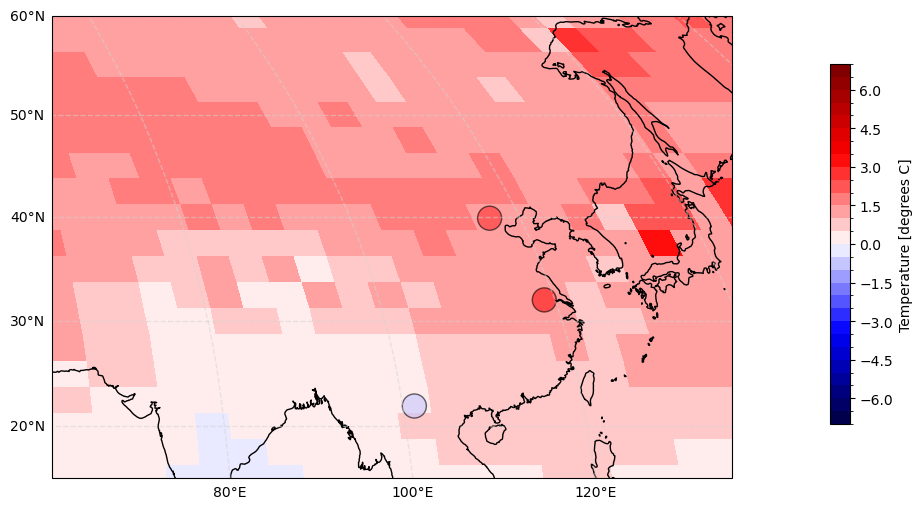

```python
fig = plt.figure(figsize=(10, 6))
ax = plt.axes(projection=ccrs.Robinson(central_longitude=0))
ax.coastlines()

# Define the extent [longitude_min, longitude_max, latitude_min, latitude_max], in this case over modern China
ax.set_extent([75, 135, 15, 60], crs=ccrs.PlateCarree())

gl = ax.gridlines(crs=ccrs.PlateCarree(), draw_labels=True,
                  linewidth=1, color='lightgray', alpha=0.5, linestyle='--')
gl.top_labels = False
gl.right_labels = False

min_level=-7
max_level=7
step_level=0.5
my_levs=np.arange(min_level, max_level+step_level, step_level)

# we have to define the colours a little differently when shading the gridboxes rather than contouring:
cmap=plt.get_cmap('seismic')

# instead of contour, use pcolormesh:
norm = mcolors.BoundaryNorm(boundaries=my_levs, ncolors=cmap.N)
mesh = ax.pcolormesh(mylonc, mylat, temp_diffc, transform=ccrs.PlateCarree(), shading='auto', norm=norm, cmap=cmap)

colorbar_axes = fig.add_axes([0.95, 0.2, 0.02, 0.6])
# edit the cbar routine to apply to mesh in place of contour:
cbar=plt.colorbar(mesh,cax=colorbar_axes,label='Temperature [degrees C]')

# plot some proxy locations on top:
# Define the locations (latitude and longitude) for the circles, and their temperature values
plon = [118.8, 116.4, 101.3]  # 3 made-up longitudes
plat = [32.06, 39.9, 21.9]  # 3 made-up latitudes
proxytemp = [3.142, 2.718, -1] # some made-up temperatures

# Define the sizes and colors for the circles
psizes = [300, 300, 300]  # Sizes in points^2.  1 point is 1/72 of an inch
#colors = ['blue', 'green', 'red']  # Colors for each circle, if you want a set colour for each point.
# If so, remove c, cmap, and norm in the lien below, and replace with color=colors .

# Plot the filled circles using plt.scatter()
ax.scatter(plon, plat, s=psizes, c=proxytemp, cmap=cmap, norm=norm,
                transform=ccrs.PlateCarree(), edgecolor='k', alpha=0.6)

plt.savefig('plots/panama_new_china.pdf', format='pdf', bbox_inches='tight')
```

**Q: Why is there a particularly strong temperature response in the region just west of Japan?**

Finally, we might want to numerically compare the proxy data with the model data at each location:

```python
# Note that this simple code relies on the proxy longitudes being in the range 0-360 degrees,
#   and will only work with this model because the model longitudes are also all in the range 0-360 degrees).

# Initialize arrays to hold the closest indices and model temperatures
closest_lonindices = []
closest_latindices = []
modeltemp = []

# nproxy id the number of proxies, in this case 3.
nproxy=len(proxytemp)

# loop over each proxy location, and calculate the closest model longiude index
for target_lon in plon:
    # Calculate the absolute differences
    differences = np.abs(mylonc - target_lon)
    # Find the index of the minimum difference
    closest_index = np.argmin(differences)
    # Store the closest index
    closest_lonindices.append(closest_index)

# same for latitude
for target_lat in plat:
    differences = np.abs(mylat - target_lat)
    closest_index = np.argmin(differences)
    closest_latindices.append(closest_index)

# again loop over proxies, putting the model temperature at that location into modeltemp.
for ii in range(nproxy):
    modeltemp.append(temp_diffc[closest_latindices[ii],closest_lonindices[ii]])

# Convert to arrays (safer for plotting and analysis)
proxytemp = np.array(proxytemp)
modeltemp = np.array(modeltemp)

# Print the extracted values at the proxy locations
for i, (lon_c, lat_c, proxy_c, model_c) in enumerate(zip(plon, plat, proxytemp, modeltemp)):
    print(f"Proxy and Model Value at location ({lon_c}, {lat_c}): {proxy_c}, {model_c}")
```

```
Proxy and Model Value at location (118.8, 32.06): 3.142, 1.036651611328125
Proxy and Model Value at location (116.4, 39.9): 2.718, 1.338470458984375
Proxy and Model Value at location (101.3, 21.9): -1.0, 0.498870849609375
```

...and then plot this as a 'scatter-plot' with the correlation coefficient and root mean squared error calculated and linear fit displayed:

```
Correlation: 0.90
RMS error: 1.69
```

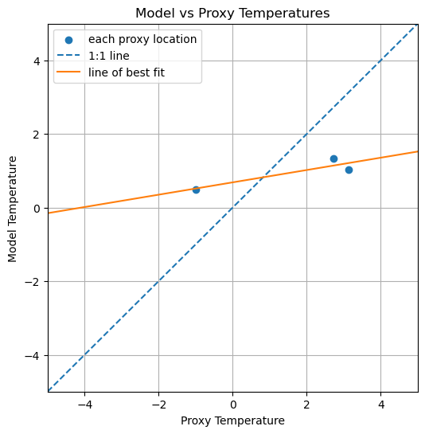

```python
# square plot
plt.figure(figsize=(6, 6))

# set the axes limits
min_val=-5.0
max_val=5.0

# Set the axis limits
plt.xlim(min_val, max_val)
plt.ylim(min_val, max_val)

# make the plot
plt.scatter(proxytemp, modeltemp, label="each proxy location")

# plot a 1:1 line
plt.plot([min_val, max_val], [min_val, max_val], linestyle='--', label="1:1 line")

# axes labels and title
plt.xlabel("Proxy Temperature")
plt.ylabel("Model Temperature")
plt.title("Model vs Proxy Temperatures")

# add grid lines
plt.grid()

# calculate a correlation coeffeicient (corr) and rms error
corr = np.corrcoef(proxytemp, modeltemp)[0,1]
rmse = np.sqrt(np.mean((modeltemp - proxytemp)**2))
# print them to the screen with 2 decimal places (.2f):
print(f"Correlation: {corr:.2f}")
print(f"RMS error: {rmse:.2f}")

# make a linear (,1) fit and plot it
m, c = np.polyfit(proxytemp, modeltemp, 1)
plt.plot([min_val,max_val], [m*min_val+c, m*max_val+c], label="line of best fit")

# add a legend, using the labels above for each symbol/line
plt.legend()

plt.savefig('plots/scatter.pdf', format='pdf', bbox_inches='tight')
```

**Q: Is the correlation coefficient a good indicator of the model-data agreement?**

### Boundary condition maps

Another thing that you may wish to do is look at some of the boundary conditions in the model. Boundary conditions are fields that the user provides to the model, and that the model cannot change. These typically include details about the land-surface (e.g. height above sea-level of the surface, soil properties), and atmospheric composition (e.g. CO2 concentration).

For example, we may wish to plot the topography, bathymetry, and land-sea mask. These can be downloaded, for example for experiment xbmsb (Pliocene open seaway):  
Orogoraphy: https://www.paleo.bristol.ac.uk/ummodel/data/xbmsb/inidata/xbmsb.qrparm.orog.nc (variable 'ht')  
Bathymetry: https://www.paleo.bristol.ac.uk/ummodel/data/xbmsb/inidata/xbmsb.qrparm.omask.nc (variable 'depthdepth')  
Land-sea mask: https://www.paleo.bristol.ac.uk/ummodel/data/xbmsb/inidata/xbmsb.qrparm.mask.nc (variable 'lsm')  
Put these files in the 'Data/panama' folder.

Let's read in these boundary conditions:

```python
file_path = 'Data/panama/xbmsb.qrparm.orog.nc'
dataset = nc.Dataset(file_path, 'r')
mydata = dataset.variables['ht'][:].data
myorog = mydata[0,0,:,:]
lat = dataset.variables['latitude']
lon = dataset.variables['longitude']
mylat = lat[:]
mylon = lon[:]
dataset.close()

file_path = 'Data/panama/xbmsb.qrparm.mask.nc'
dataset = nc.Dataset(file_path, 'r')
mydata = dataset.variables['lsm'][:].data
mylsm = mydata[0,0,:,:]
dataset.close()

file_path = 'Data/panama/xbmsb.qrparm.omask.nc'
dataset = nc.Dataset(file_path, 'r')
mydata = dataset.variables['depthdepth'][:].data
# note that bathymetry is 2-dimensional, not 4-dimensional, and we make it negative
mybath = mydata[:,:]*-1
#Retrieve lat and lon in the ocean (in this version of the model,
#  the ocean resolution is 1.25 degrees by 1.25 degrees, higher than the atmos resolution of 3.75 degrees by 2.5 degrees)
lato = dataset.variables['latitude']
lono = dataset.variables['longitude']
mylato = lato[:]
mylono = lono[:]
dataset.close()
```

In order to plot these, we will first need to set up a nice colour table that has orography-like colors for the land and blues for the ocean:

```python
# SET UP THE TOPOGRAPHY COLOURMAP

# set up teh colours for orography (land) and bathymetry (ocean) colourmaps
colors_orography = [(0, 'green'), (0.5, 'yellow'), (0.8, 'brown'), (1, 'white')]
colors_bathymetry = [(0, 'darkblue'), (0.3, 'blue'), (1, 'lightblue')]

# Create the two colormaps
orog_colormap = mcolors.LinearSegmentedColormap.from_list('orog_colormap', colors_orography, N=256)
bathy_colormap = mcolors.LinearSegmentedColormap.from_list('bathy_colormap', colors_bathymetry, N=256)

# Combine the two colormaps
combined_colors = np.vstack((
    bathy_colormap(np.linspace(0, 1, 128)),
    orog_colormap(np.linspace(0, 1, 128))
))
combined_colormap = mcolors.LinearSegmentedColormap.from_list('combined_colormap', combined_colors)
```

```python
# Mask orography

# we only want to plot the orography where there is land, not ocean, otherwise it will overlay the bathymetry,
#   so make a new variable that is masked where there is ocean (lsm=0):
myorog_land = np.ma.masked_where(mylsm == 0, myorog)
```

Now make the plot:

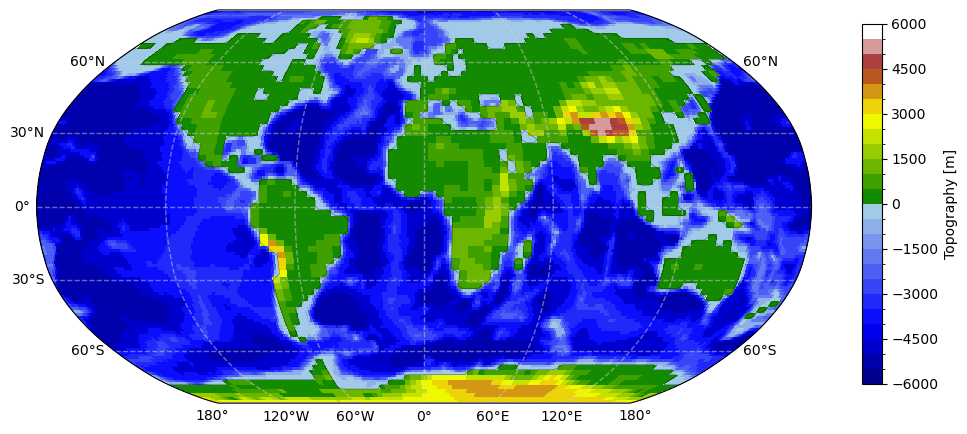

```python
mylsmc=cutil.add_cyclic_point(mylsm)
mylonc=np.ma.append(mylon,mylon[0]+360.0)

fig = plt.figure(figsize=(10, 6))
ax = plt.axes(projection=ccrs.Robinson(central_longitude=0))
gl = ax.gridlines(crs=ccrs.PlateCarree(), draw_labels=True,
                  linewidth=1, color='lightgray', alpha=0.5, linestyle='--')
gl.top_labels = False
gl.right_labels = False
min_level=-6000
max_level=6000
step_level=500
my_levs=np.arange(min_level, max_level+step_level, step_level)

# use the combined colormap
cmap=combined_colormap
norm = mcolors.BoundaryNorm(boundaries=my_levs, ncolors=cmap.N)
# plot the bathymetry:
mesh = ax.pcolormesh(mylono, mylato, mybath, transform=ccrs.PlateCarree(), shading='auto', norm=norm,cmap=cmap)
# plot the orography over land only:
mesh = ax.pcolormesh(mylon, mylat, myorog_land, transform=ccrs.PlateCarree(), shading='auto', norm=norm,cmap=cmap)

# Here we add our own continentnal outline from the land-sea mask file.  Contour the mask (0 or 1) with a single
#   contour with a value of 0.5
plt.contour(mylonc, mylat, mylsmc, levels=[0.5], colors='black', linewidths=0.2, transform=ccrs.PlateCarree())

colorbar_axes = fig.add_axes([0.95, 0.2, 0.02, 0.6])
cbar=plt.colorbar(mesh,cax=colorbar_axes,label='Topography [m]')

plt.savefig('plots/topography.pdf', format='pdf', bbox_inches='tight')
```

**Q: How does the height of the Himalaya region compare with reality? What impact might this have on the model results?**

You are now armed with the main tools to start your analysis!

## Part 5: Automation

### Reading in multiple files

It is often useful to automate the reading of multiple files. To do this we use 'loops', which are generally useful for reading in and handling large quantities of data. We already used one when comparing proxy and model data earlier in the handbook, but we can also use these for reading in lots of files.

Here as an example we will use a simulation from Valdes et al (2021), from the 'Foster CO2' Phanerozoic series, which is also known as the 'scotese_02' series in Judd et al (2024), and the 'texp' series internally in Bristol. 'texps2' is a Turonian (mid-Cretaceous, 92 million years ago; 92Ma) simulation from that series.

Surface atmospheric variables, such as surface temperature which we examined earlier, are available for simulation. The link for the annual means is:  
https://www.paleo.bristol.ac.uk/ummodel/data/texps2/climate/texps2a.pdclann.nc  
where 'ann' can be changed to a specific month, i.e. 'jan', 'feb', 'mar', 'apr', 'may', 'jun', 'jul', 'aug', 'sep', 'oct', 'nov', or 'dec'.

The examples below assume that you have downloaded all 12 months to a 'texps2' folder within your 'Data' folder.

This code reads in March to May in one go, via a loop:

```python
# These are names for the files:
months= ['mar','apr','may']
variable='precip_mm_srf'
file_path= 'Data/texps2/texps2a.pdcl'

# This is an empty stack to store outputs
seasonal_variable_stack= []

# here we loop over the 12 months; each time the code goes through the loop, variable 'month' will be
#   one of the elements of 'months'
for month in months:

    filename= f'{file_path}{month}.nc'

    dataset = nc.Dataset(filename, 'r')

    #Extract variables
    extractvariable = dataset.variables[variable][:].data
    myvariable = extractvariable[0, 0, :, :]

    #Apply unit correction, kg/m2/s to mm/day :
    processed_variable = myvariable*86400

    #Store in the stack
    seasonal_variable_stack.append(processed_variable)

    # Close the dataset
    dataset.close()
```

You now have a stack of 3 months of mean precipitation in mm/day for the mid-Cretaceous. Let's plot the March-April-May (MAM) seasonal mean.

We first need to calculate the mean from the stack, and then read in the land-sea mask (download this from https://www.paleo.bristol.ac.uk/ummodel/data/texps2/inidata/texps2.qrparm.mask.nc , and put in the directory Data/texps2 ).

We will assume that `lat` and `lonc` are already read in above.

```python
# calculate seasonal mean:

# convert to a numpy array
seasonal_array = np.array(seasonal_variable_stack)
# note that in Python, '0:3' means start at 0, and go to the third index.  Python starts its indexing at zero, so
#  this will take the average of march, april, and may:
mean_mam=np.mean(seasonal_array[0:3, :, :], axis=0)
```

```python
# read in land-sea mask:

file_path = 'Data/texps2/texps2.qrparm.mask.nc'
dataset = nc.Dataset(file_path, 'r')
mydata = dataset.variables['lsm'][:].data
mylsm = mydata[0,0,:,:]
dataset.close()
```

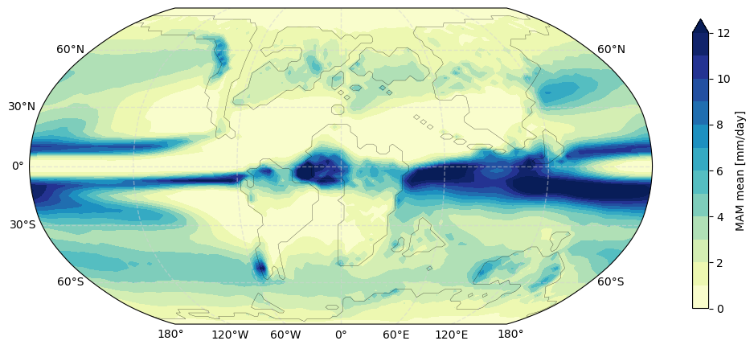

```python
mean_mamc=cutil.add_cyclic_point(mean_mam)
mylsmc=cutil.add_cyclic_point(mylsm)

fig = plt.figure(figsize=(10, 6))
ax = plt.axes(projection=ccrs.Robinson(central_longitude=0))

gl = ax.gridlines(crs=ccrs.PlateCarree(), draw_labels=True,
                  linewidth=1, color='lightgray', alpha=0.5, linestyle='--')
gl.top_labels = False
gl.right_labels = False

min_level = 0
max_level = 12
step_level = 1
my_levs = np.arange(min_level, max_level + step_level, step_level)

# use the YlGnBu colour map for precipitation; extend the colour scale at the top end:
contour=plt.contourf(mylonc, mylat, mean_mamc, transform=ccrs.PlateCarree(central_longitude=0),
                     levels=my_levs,cmap='YlGnBu',extend='max')

plt.contour(mylonc, mylat, mylsmc, levels=[0.5], colors='black', linewidths=0.2, transform=ccrs.PlateCarree())

colorbar_axes = fig.add_axes([0.95, 0.2, 0.02, 0.6])
cbar = plt.colorbar(contour, cax=colorbar_axes, label='MAM mean [mm/day]')

plt.savefig('plots/precip_texps2_mam.pdf', format='pdf', bbox_inches='tight')
plt.show()
```

**Q: How does this precipitation pattern compare with the precipitation in our Pliocene xbmsa simulation? What cuases the differnces?**

### Functions

If you want to read in multiple simulations, or multiple variables, it is more efficient to express the code that reads in the variable as a function that you can call multiple times, making your code more human-readable, shorter, and easier to edit consistently.

You define a function in a cell, run that cell, and then the function can be called multiple times from other cells:

```python
# Define the function:

# It will take inputs of a list of months, a variable name, and experiment name, and a unit conversion factor,
#   and output a stacked variable:
def load_data(months, variable, expname, conversion):

    monthly_variable_stack = []

    file_path=f"Data/{expname}/{expname}a.pdcl"

    for month in months:
        filename = f'{file_path}{month}.nc'

        dataset = nc.Dataset(filename, 'r')

        extractvariable = dataset.variables[variable][:].data
        myvariable = extractvariable[0, 0, :, :]
        processed_variable = conversion*myvariable
        monthly_variable_stack.append(processed_variable)

    return monthly_variable_stack
```

Now your function 'load_data' can easily load in data, as long as the variable follows the same structure as the single-level, single-time data we have examined so far. Multi-level data, such as temperature at multiple atmospheric levels, requires a bit of tweaking to the indexing step.

Functions can be useful where you need to repeat loops, or embed a looped workflow (e.g. across multile simulations) within another loop (e.g. across multiple months).

If you had downloaded all the months for 'texps2', you could use the function to extract precipitation like this:

```python
months = ['jan', 'feb', 'mar', 'apr', 'may', 'jun', 'jul', 'aug', 'sep', 'oct', 'nov', 'dec']
variable = 'precip_mm_srf'
expname = 'texps2'
conversion = 86400.0

monthly_variable_stack_texps2 = load_data(months, variable, expname, conversion)
```

You now have a new object 'monthly_variable_stack_texps2' with 12 months of data.

To edit the months, variable of interest, and/or simulation, the function itself does not have to change, just your input parameters to the function.

We can also make a function to read in the land-sea mask:

```python
# Define the function:
def load_lsmdata(expname):

    file_path = f"Data/{expname}/{expname}.qrparm.mask.nc"
    dataset = nc.Dataset(file_path, 'r')
    mydata = dataset.variables['lsm'][:].data
    mylsm = mydata[0,0,:,:]
    dataset.close()

    return(mylsm)
```

We can do the same to make our plotting simpler and more efficient:

```python
# Define the function:

# It will take longitudes, latitudes, a variable to be plotted, a colorscale, a coastline variable (lsm), axes definitions
#   (min_level,max_level,step_level,caps), an legend label, and a filename
def plot_var(lons,lats,variable,colorscale,lsm,min_level,max_level,step_level,caps,leglabel,filename):

    # Add a cyclic point to the variable and the coastline and the longitudes:
    variablec=cutil.add_cyclic_point(variable)
    lsmc=cutil.add_cyclic_point(lsm)
    mylonc=np.ma.append(mylon,mylon[0]+360.0)

    fig = plt.figure(figsize=(10, 6))
    ax = plt.axes(projection=ccrs.Robinson(central_longitude=0))

    gl = ax.gridlines(crs=ccrs.PlateCarree(), draw_labels=True,
                    linewidth=1, color='lightgray', alpha=0.5, linestyle='--')
    gl.top_labels = False
    gl.right_labels = False

    my_levs = np.arange(min_level, max_level + step_level, step_level)

    contour=plt.contourf(mylonc, mylat, variablec, transform=ccrs.PlateCarree(central_longitude=0),
                     levels=my_levs,cmap=colorscale,extend=caps)

    plt.contour(mylonc, mylat, mylsmc, levels=[0.5], colors='black', linewidths=0.2, transform=ccrs.PlateCarree())

    colorbar_axes = fig.add_axes([0.95, 0.2, 0.02, 0.6])
    cbar = plt.colorbar(contour, cax=colorbar_axes, label=leglabel)

    plt.savefig(f"plots/{filename}.pdf", format='pdf', bbox_inches='tight')
    plt.show()
```

Now that these functions are defined, to read, calculate and plot the JJA-DJF mean of simulation texps2:

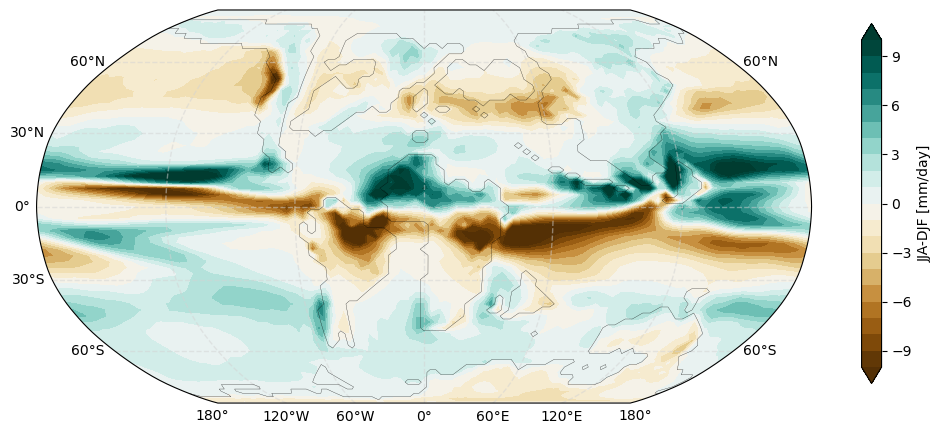

```python
expname = 'texps2'
monthly_variable_stack_texps2 = load_data(months, variable, expname, conversion)
lsm_texps2 = load_lsmdata(expname)
seasonal_array = np.array(monthly_variable_stack_texps2)
mean_jja_texps2=np.mean(seasonal_array[5:8, :, :], axis=0)
mean_djf_texps2=np.mean(seasonal_array[[11,0,1], :, :], axis=0)
seas_range=mean_jja_texps2-mean_djf_texps2
plot_var(mylon,mylat,seas_range,'BrBG',lsm_texps2,-10,10,1,'both',
         'JJA-DJF [mm/day]','precip_texps2_jja-djf')
```

**Q: Based on these results, can you plot a new variable that indicates monsoon (high precipitation seasonality) strength?**

### Phanerozoic paleo rotations

```python
# define the URL:
url = "https://gws.gplates.org/reconstruct/reconstruct_points/"
params = {
    "points": "32.2,48.9",
    "time": 66,
    "model": "PALEOMAP"
}
# Use json to extract the data from the webpage, passing arguments:
response = requests.get(url, params=params)
data = response.json()

# Get the paleo longitude and latitude into separate variables and print:
pal_lon, pal_lat = data["coordinates"][0]
print(pal_lon)
print(pal_lat)
```

```
26.7519
41.8311
```

## Part 6: Other analysis and plotting tools

### Global and regional means

A useful tool when analysing climate model outputs is to calculate the mean value of some variable over some region of the Earth. Most commonly this will be a global mean. Unfortunately you can't just average all the values in an array, because each model gridcell has a different area, and we need to account for this. To do this, we can make a vriable that is the relative area of each gridcell, where teh sium of all the relative areas adds up to 1.

The equation for the area of a gridcell, $A_i$, with latitude edges $\phi^+_i$ and $\phi^-_i$, and longitude edges $\lambda^+_i$ and $\lambda^-_i$, with $N$ gridcells is: $$ A_i=\sum_i^N = \frac{1}{4\pi}( sin(\phi^+_i)-sin(\phi^-_i) )(\lambda^+_i - \lambda^-_i) $$ where $\phi$ and $\lambda$ are in radians.

The longitudes in the model are offset from the centres by 3.75/2 degrees, and the latitudes are offset by 2.5/2 degrees (but with a slight adjustment at the poles due to the centres of the most poleward gridboxes being incorrectly defined in the output netcdf files). So, the gridbox areas can be defined, adn plotted using:

```
[ -1.875   1.875   5.625   9.375  13.125  16.875  20.625  24.375  28.125
  31.875  35.625  39.375  43.125  46.875  50.625  54.375  58.125  61.875
  65.625  69.375  73.125  76.875  80.625  84.375  88.125  91.875  95.625
  99.375 103.125 106.875 110.625 114.375 118.125 121.875 125.625 129.375
 133.125 136.875 140.625 144.375 148.125 151.875 155.625 159.375 163.125
 166.875 170.625 174.375 178.125 181.875 185.625 189.375 193.125 196.875
 200.625 204.375 208.125 211.875 215.625 219.375 223.125 226.875 230.625
 234.375 238.125 241.875 245.625 249.375 253.125 256.875 260.625 264.375
 268.125 271.875 275.625 279.375 283.125 286.875 290.625 294.375 298.125
 301.875 305.625 309.375 313.125 316.875 320.625 324.375 328.125 331.875
 335.625 339.375 343.125 346.875 350.625 354.375 358.125]
[ 90.    88.75  86.25  83.75  81.25  78.75  76.25  73.75  71.25  68.75
  66.25  63.75  61.25  58.75  56.25  53.75  51.25  48.75  46.25  43.75
  41.25  38.75  36.25  33.75  31.25  28.75  26.25  23.75  21.25  18.75
  16.25  13.75  11.25   8.75   6.25   3.75   1.25  -1.25  -3.75  -6.25
  -8.75 -11.25 -13.75 -16.25 -18.75 -21.25 -23.75 -26.25 -28.75 -31.25
 -33.75 -36.25 -38.75 -41.25 -43.75 -46.25 -48.75 -51.25 -53.75 -56.25
 -58.75 -61.25 -63.75 -66.25 -68.75 -71.25 -73.75 -76.25 -78.75 -81.25
 -83.75 -86.25 -88.75 -90.  ]
1.0
```

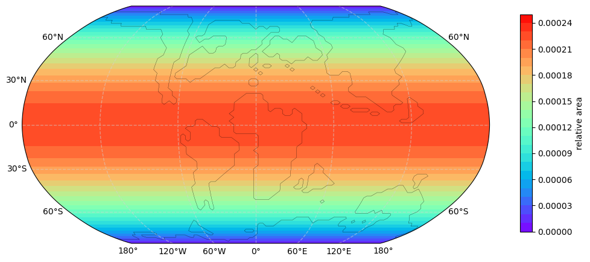

```python
mylon_edge=mylon-3.75/2.0
mylon_edge=np.append(mylon_edge,mylon[-1]+3.75/2.0)
print(mylon_edge)
mylon_edge=mylon_edge*2.0*np.pi/360.0

mylat_edge=mylat+2.5/2.0
mylat_edge[0]=90.0
mylat_edge=np.append(mylat_edge,-90.0)
print(mylat_edge)
mylat_edge=mylat_edge*2.0*np.pi/360.0

nlon = len(mylon)
nlat = len(mylat)

# Create empty area array
area = np.zeros((nlat, nlon))

# Loop over grid
for j in range(nlat):
    for i in range(nlon):
        area[j, i] = ( mylon_edge[i+1] - mylon_edge[i] ) * ( np.sin(mylat_edge[j]) - np.sin(mylat_edge[j+1]) )

# normalise to 1.0
area=area/(4.0*np.pi)
# and check, should be 1
print(np.sum(area))

plot_var(mylon,mylat,area,'rainbow',mylsm,0,0.00025,0.00001,'neither',
         'relative area','gridbox_area')
```

**Q: Can you explain why the plot looks like this?**

Using the data from Lunt et al (2008) again, we have mytemp_1 and mytemp_2 for the annual mean closed and open Panama seaway simulations, respectively.

```python
global_mean_temp_1=np.sum(mytemp_1*area)
global_mean_temp_2=np.sum(mytemp_2*area)
print(global_mean_temp_1-global_mean_temp_2)
```

```
0.2516300526942814
```

**Q: Can you explain why the global mean response is so small, despite large regional changes in your first plot?**

We are not restricted to the global mean, and can use the approach above to calcukate regional means. For example, to calculate the mean over the Northern and Southern Hemisheres separately:

```python
nh_mask = mylat[:, None] > 0   # make teh mask possible to 'stretch' to (lat, lon) via 'broadcasting' as below
sh_mask = mylat[:, None] <= 0
nh_mean_1 = np.sum(mytemp_1 * area * nh_mask) / np.sum(area * nh_mask)
sh_mean_1 = np.sum(mytemp_1 * area * sh_mask) / np.sum(area * sh_mask)
nh_mean_2 = np.sum(mytemp_2 * area * nh_mask) / np.sum(area * nh_mask)
sh_mean_2 = np.sum(mytemp_2 * area * sh_mask) / np.sum(area * sh_mask)

print(nh_mean_1-nh_mean_2)
print(sh_mean_1-sh_mean_2)
```

```
1.0986839307602168
-0.5592560551841075
```

This shows that the hemispheric means are however substantial, as you can see in the plot we first made.

### Other plotting tools

#### Masking

Masking can be a useful tool when displaying data. For example, we may wish to mask out the precipitation over ocean (i.e. where the land-sea mask is equal to zero) :

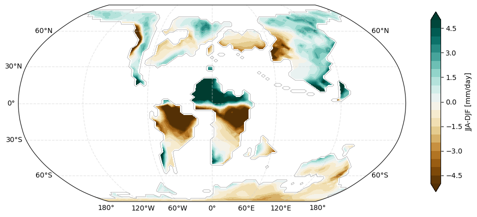

```python
# apply the mask:
precip_masked=np.ma.masked_where(lsm_texps2==0,seas_range)
plot_var(mylon,mylat,precip_masked,'BrBG',lsm_texps2,-5,5,0.5,'both',
         'JJA-DJF [mm/day]','precip_texps2_jja-djf_masked')
```

**Q: Why is the JJA-DJF precipitation so small right along the equator in Africa**

You could make the masked region more obvious by setting the background to grey (hex code #B0B0B0), by adding `ax.set_facecolor('#B0B0B0')` to your plotting function.

#### Highlighting regions

If you wanted to highlight a region on the map, you can do so by describing a polygon, for eaxmple:

```python
# Define the polygon:
lon_start = 315
width = 130
lat_start = -30
height = 30
# Create the rectangle
rect = mpatches.Rectangle((lon_start, lat_start),
                          width, height,
                          linewidth=1.5, edgecolor='red',
                          facecolor='none',
                          transform=ccrs.PlateCarree())
```

Then add the rectangle to your plotting function by adding: `ax.add_patch(rect)` to your plotting function.

#### Bar charts

Bar charts can be useful for showing seasonal cycles. Here we make a bar chart showing the seasonal cycle of precipitation at the paleo location of plon[0] and plat[0] defined above.

First set some things up and extract the data:

```python
# print the modern lons/lats:
print(plon[0],plat[0])

# first extract the paleo latitude and longitude and print:
url = "https://gws.gplates.org/reconstruct/reconstruct_points/"
params = {
    "points": f"{plon[0]},{plat[0]}",
    "time": 92,
    "model": "PALEOMAP"
}
response = requests.get(url, params=params)
data = response.json()
pal_lon, pal_lat = data["coordinates"][0]
print(pal_lon,pal_lat)

# then find the nearest model gridcell:
closest_lon_index = np.argmin(np.abs(mylon - pal_lon))
closest_lat_index = np.argmin(np.abs(mylat - pal_lat))

# check that the model lon/lat makes sense:
print(mylon[closest_lon_index],mylat[closest_lat_index])

# Extract the data for 12 months at this location:
precip_values = []
for month_data, month in zip(monthly_variable_stack_texps2, months):
    precip_values.append(month_data[closest_lat_index, closest_lon_index])
```

```
118.8 32.06
111.9202 36.5098
112.5 37.5
```

...and then make the bar chart (this time, just plot it to the screen, don't save it):

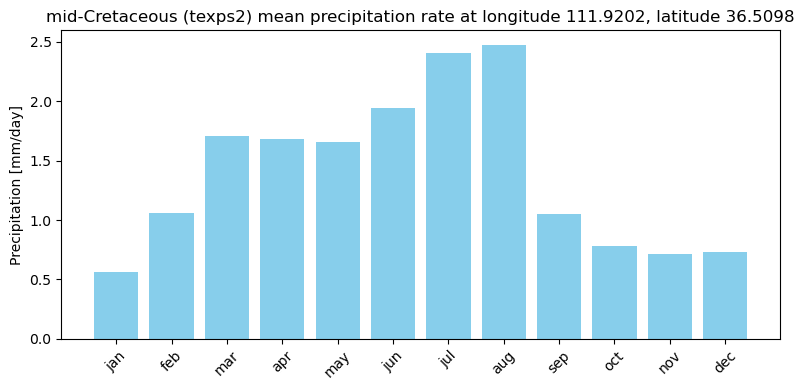

```python
# and make the bar chart:
plt.figure(figsize=(8, 4))
plt.bar(months, precip_values, color='skyblue')
plt.ylabel('Precipitation [mm/day]')
plt.title(f'mid-Cretaceous (texps2) mean precipitation rate at longitude {pal_lon}, latitude {pal_lat}')
plt.xticks(rotation=45)
plt.tight_layout()
plt.show()
```

#### Dual axes and line plots

We might want to present data from two variables on the same plot. Here we add temperature to the plot above.

```python
variable = 'temp_mm_1_5m'
conversion = 1.0
monthly_temp_stack_texps2 = load_data(months, variable, expname, conversion)
```

Then repeat the code to extract surface temperature from our point of interest:

```python
temp_values = []
for month_data, month in zip(monthly_temp_stack_texps2, months):
    temp_values.append(month_data[closest_lat_index, closest_lon_index])
print(temp_values)
```

```
[np.float32(277.08176), np.float32(281.461), np.float32(286.76175), np.float32(293.7265), np.float32(301.4713), np.float32(307.5851), np.float32(309.25162), np.float32(307.6589), np.float32(303.2468), np.float32(295.59045), np.float32(285.80737), np.float32(279.44418)]
```

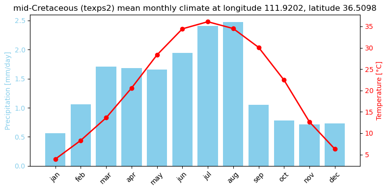

```python
fig, ax1 = plt.subplots(figsize=(8, 4))

# The first bar plot for precipitation
ax1.bar(months, precip_values, color='skyblue')
ax1.set_ylabel('Precipitation [mm/day]', color='skyblue')
ax1.tick_params(axis='y', labelcolor='skyblue')

# Title and x-axis
ax1.set_title(f'mid-Cretaceous (texps2) mean monthly climate at longitude {pal_lon}, latitude {pal_lat}')
ax1.set_xticks(range(len(months)))
ax1.set_xticklabels(months, rotation=45)

# Second axis for temperature
ax2 = ax1.twinx()
# convert to a numpy array and to celsius:
temp_values= np.array(temp_values)-273.15
ax2.plot(months, temp_values, color='red', marker='o', linewidth=2)
ax2.set_ylabel('Temperature [°C]', color='red')
ax2.tick_params(axis='y', labelcolor='red')

plt.tight_layout()
plt.show()
```

**Q: Why is the temperature seasonality similar to the precipitation seasonality?**

## Coda

Congratulations on completing this handbook on plotting and analysing paleoclimate model outputs! These maps, plots and techniques should be enough to get you started with analysing climate model outputs.

## References

Judd, E.J., Tierney, J.E., Lunt, D.J., Montanez, I.P., Huber, B.T., Wing, S.L., Valdes, P.J., A 485-million-year history of Earth’s surface temperature, Science, 385,eadk3705(2024). doi:10.1126/science.adk3705

Lunt, D.J., Valdes, P.J., Haywood, A., Rutt, I. (2008). Closure of the Panama Seaway during the Pliocene: Implications for climate and Northern Hemisphere glaciation. Climate Dynamics, 30, 1-18.

Malanoski, C.M., Farnsworth, A., Lunt, D.J., Valdes, P.J., Saupe, E.E., Climate change is an important predictor of extinction risk on macroevolutionary timescales, Science, 383, 1130-1134, 2024. DOI:10.1126/science.adj5763

Valdes, P. J., Armstrong, E., Badger, M. P. S., Bradshaw, C. D., Bragg, F., Crucifix, M., Davies-Barnard, T., Day, J. J., Farnsworth, A., Gordon, C., Hopcroft, P. O., Kennedy, A. T., Lord, N. S., Lunt, D. J., Marzocchi, A., Parry, L. M., Pope, V., Roberts, W. H. G., Stone, E. J., Tourte, G. J. L., and Williams, J. H. T.: The BRIDGE HadCM3 family of climate models: HadCM3@Bristol v1.0, Geosci. Model Dev., 10, 3715-3743, 2017.

Valdes, P. J., Scotese, C. R., and Lunt, D. J.: Deep ocean temperatures through time, Clim. Past, 17, 14831506, https://doi.org/10.5194/cp-17-1483-2021, 2021.